# Airline on-time performance

Every passenger has experienced the chaos of air travel like the waiting, the last-minute delays, and the cancellation notice. This analysis begins with a simple question: Can we find the hidden pattern behind the disruptions in the skies?

Using an "Airline On-Time Performance" dataset from Kaggle, we want to identify and explain the factors and patterns influencing flight delays and cancellations.

The analysis address key questions across four main areas:

1. **Delay Patterns** : Examine how delays vary by time of day, day of week, and season.
2. **Delay Factors** : Identify what could be contributing to delays, such as carrier, weather or other factors?
3. **Cancellation Analysis** : Explore the main reasons for cancellations and determine if they are linked to specific airlines, airports or months?
4. **Problematic Routes** : Identify which routes that consistently underperform and seek to understand the root causes of their operational challenges.

To efficiently handle this large dataset, we used Hive for data storage and retrieval. SQL queries is also being implemented to extract specific information from the dataset for our analysis.

## Data Relationship

The dataset itself is composed of multiple interconnected tables, with a total of four tables available. For this project, we focused exclusively on the 2007 tables to perform our analysis. The figure below illustrates the relationships between all the tables and the keys that link them.

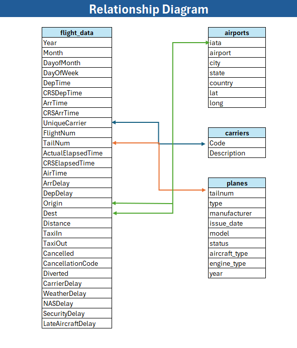

# Step 1: Importing data into Hive

### Pre-requisites:

1. Putty and PSCP: You should have Putty installed alongside with PSCP (Putty Secure Copy Protocol) - usually PSCP will be downloaded together.
2. Hortonworks Sandbox Running: Oracle VirtualBox VM with Hortonworks Sandbox should be running and accessible.
3. SSH Access: maria_dev@127.0.0.1
   - maria_dev is username
   - 127.0.0.1 is the IP (this is often localhost or 127.0.0.1 when using port forwarding from the VM), and
   - 2222 is the forwarded port for SSH.
4. CSV Files: All the necessary files should be in the local file Windows PC.

### To uploading data into HDFS system

1. using cmd: run `pscp -r -P 2222 "C:\Users\airline" maria_dev@127.0.0.1:/home/maria_dev/` - *need to change according to file directory path*
2. On PuTTy with configured SSH host name, run run:
   - `ls /home/maria_dev/` to check if the folder exists
   - `hdfs dfs -mkdir -p /user/maria_dev/airline/input` - to create a folder in hdfs
   - `hdfs dfs -put /home/maria_dev/airline/* /user/maria_dev/airline/input` to copy files from local VM to HDFS
   - `hdfs dfs -ls /user/maria_dev/airline/input` - to check the files

### To upload CSV files from HDFS to Hive

i) To create a table called *Flight_Data* imported from *2007.csv* file, using query as below:

```
CREATE EXTERNAL TABLE IF NOT EXISTS Flight_Data (
    Year STRING,
    Month STRING,
    DayofMonth STRING,
    DayOfWeek STRING,
    DepTime STRING,
    CRSDepTime STRING,
    ArrTime STRING,
    CRSArrTime STRING,
    UniqueCarrier STRING,
    FlightNum STRING,
    TailNum STRING,
    ActualElapsedTime INT,
    CRSElapsedTime INT,
    AirTime INT,
    ArrDelay INT,
    DepDelay INT,
    Origin STRING,
    Dest STRING,
    Distance INT,
    TaxiIn INT,
    TaxiOut INT,
    Cancelled STRING,
    CancellationCode STRING,
    Diverted STRING,
    CarrierDelay INT,
    WeatherDelay INT,
    NASDelay INT,
    SecurityDelay INT,
    LateAircraftDelay INT
)
ROW FORMAT DELIMITED FIELDS TERMINATED BY ','
STORED AS TEXTFILE
LOCATION 'hdfs://sandbox-hdp.hortonworks.com:8020/user/maria_dev/airline/2007.csv'
TBLPROPERTIES ("skip.header.line.count"="1");
```

ii) *carriers.csv*

```
CREATE EXTERNAL TABLE IF NOT EXISTS Carriers (
  Code STRING,
  Description STRING
)
ROW FORMAT DELIMITED
FIELDS TERMINATED BY ','
STORED AS TEXTFILE
LOCATION 'hdfs://sandbox-hdp.hortonworks.com:8020/user/maria_dev/airline/carriers.csv'
TBLPROPERTIES ("skip.header.line.count"="1");
```

iii) *airports.csv*

```
CREATE EXTERNAL TABLE IF NOT EXISTS Airports (
  iata STRING,
  airport STRING,
  city STRING,
  state STRING,
  country STRING,
  lat STRING, -- Consider DOUBLE or DECIMAL if these are actual latitude/longitude
  longs STRING -- Consider DOUBLE or DECIMAL
)
ROW FORMAT DELIMITED
FIELDS TERMINATED BY ',' -- Ensure standard single quotes
STORED AS TEXTFILE
LOCATION 'hdfs://sandbox-hdp.hortonworks.com:8020/user/maria_dev/airline/airports.csv'
TBLPROPERTIES ("skip.header.line.count"="1");
```

iv) *plane-data.csv*

```
CREATE EXTERNAL TABLE IF NOT EXISTS Planes (
  tailnum STRING,
  type STRING,
  manufacturer STRING,
  issue_date STRING,
  model STRING,
  status STRING,
  aircraft_type STRING,
  engine_type STRING,
  year INT
)
ROW FORMAT SERDE 'org.apache.hadoop.hive.serde2.OpenCSVSerde' -- Changed to OpenCSVSerde for better CSV parsing
WITH SERDEPROPERTIES (
  "separatorChar" = ",",    -- Ensure standard double quotes for property values
  "quoteChar"     = "\"",   -- For handling quoted fields (e.g., "Boeing, Inc.")
  "escapeChar"    = "\\"    -- For handling escaped quotes or delimiters within fields
)
STORED AS TEXTFILE
LOCATION 'hdfs://sandbox-hdp.hortonworks.com:8020/user/maria_dev/airline/plane-data.csv'
TBLPROPERTIES ("skip.header.line.count"="1");
```

All files are succesfully uploaded into HIVE !

[figure not shown]

# Step 2: Loading libraries and connecting Hive with Python Notebook

```python
#importing packages

import pandas as pd
import numpy as np
import matplotlib.pyplot as plt
import seaborn as sns
from datetime import datetime as dt
import os
import warnings #to filter warnings
from impala.dbapi import connect
import warnings

#Connecting Hive with Python Notebook
conn = connect(host="127.0.0.1",
               port=10000,
               user="maria_dev",
               database = "default",
               auth_mechanism='PLAIN')
cursor = conn.cursor()
```

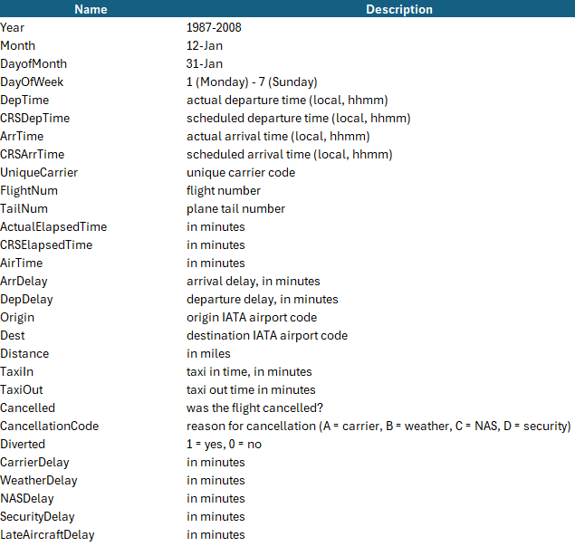

# Step 3: Data Exploration

## 📈 Delay Pattern

Discovering delay patterns allow us to examine how flight delays vary over time. Here we want to see the performance across different time dimensions. Specifically, we want to investigate:

### What times of day (morning/afternoon/evening) have the lowest average delays?

The reason we chose scheduled departure time instead of actual departure time because it is more appropriate as the variable represents the intended time for the flight. When a passenger books a flight or an airline schedules it, it's based on this time. Analyzing delays by scheduled time reveals which time slots (regardless of when the flight actually left) are inherently more prone to delays.

```python
query = """
SELECT
  TimeDuration,
  AVG(ArrDelay) AS Avg_Arrival_Delays,
  AVG(DepDelay) AS Avg_Departure_Delay
FROM (
  SELECT *,
    CASE
      WHEN CRSDepTime BETWEEN 600 AND 1159 THEN 'Morning'
      WHEN CRSDepTime BETWEEN 1200 AND 1759 THEN 'Afternoon'
      WHEN CRSDepTime BETWEEN 1800 AND 2059 THEN 'Evening'
      ELSE 'Late Night/Early Morning'
    END AS TimeDuration
  FROM flight_data
  WHERE Cancelled = 0
) AS binned_data
GROUP BY TimeDuration

"""

delay_bytime = pd.read_sql(query, conn)
delay_bytime.head(10)
```

|  | timeduration | avg_arrival_delays | avg_departure_delay |
| --- | --- | --- | --- |
| 0 | Afternoon | 13.220206 | 14.123133 |
| 1 | Evening | 17.519099 | 19.299951 |
| 2 | Late Night/Early Morning | 11.961175 | 13.724156 |
| 3 | Morning | 4.222742 | 5.410461 |

```python
#to order custom
ordered_time = ['Morning','Afternoon','Evening','Late Night/Early Morning']

delay_bytime['timeduration'] = pd.Categorical(delay_bytime['timeduration'], categories = ordered_time, ordered = True)
delay_bytime = delay_bytime.sort_values(by = 'timeduration')
delay_bytime
```

|  | timeduration | avg_arrival_delays | avg_departure_delay |
| --- | --- | --- | --- |
| 3 | Morning | 4.222742 | 5.410461 |
| 0 | Afternoon | 13.220206 | 14.123133 |
| 1 | Evening | 17.519099 | 19.299951 |
| 2 | Late Night/Early Morning | 11.961175 | 13.724156 |

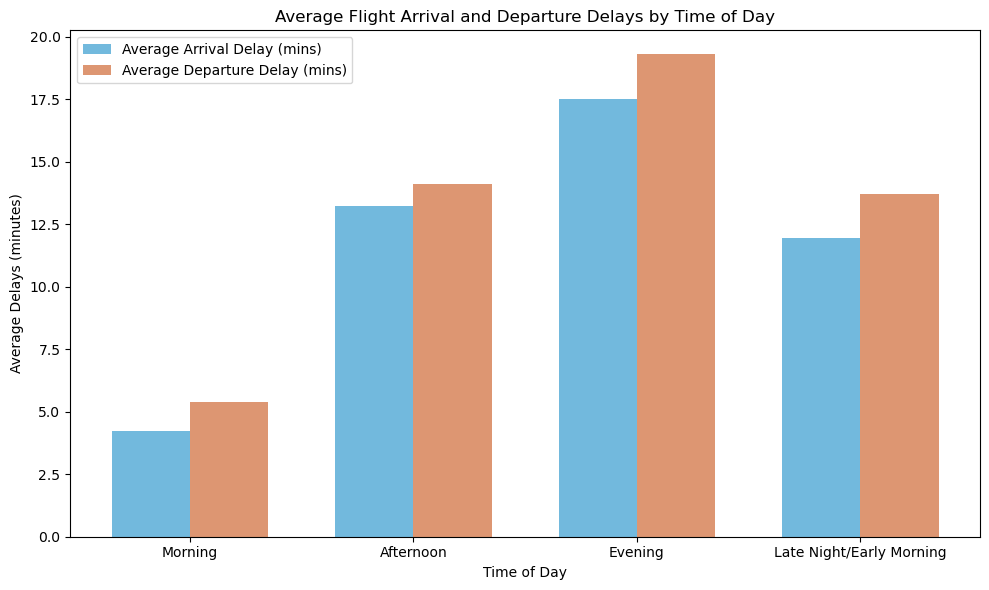

```python
#to produce plots

plt.figure(figsize=(10, 6))

bar_width = 0.35
index = range(len(delay_bytime)) #from 0 to 4


# Create bars
plt.bar(index, delay_bytime['avg_arrival_delays'], bar_width, label='Average Arrival Delay (mins)', color='#72B9DD')
plt.bar([i + bar_width for i in index], delay_bytime['avg_departure_delay'], bar_width, label='Average Departure Delay (mins)', color='#DD9672')

plt.title('Average Flight Arrival and Departure Delays by Time of Day')
plt.xlabel('Time of Day')
plt.ylabel('Average Delays (minutes)')
plt.xticks([i + bar_width / 2 for i in index], delay_bytime['timeduration'])
plt.legend()


plt.tight_layout() # Adjust plot to prevent labels from overlapping\
plt.show()
```

The plot clearly illustrates the average delay, measured in minutes, for both flight departures and arrivals, grouped by different times of day.

From the plot, we can observe that **Evening** time demonstratres the **most significant** average delays for both departures and arrivals. The average delay is notably higher compared to other periods. It is reasonable as the time associated with nighttime operations. Factors such as reduced visibility for pilots and ground crews, combined with potential worsening weather conditions, could cumulatively increase delays. Furthermore, late evening flights are often the last flights of the day of an aircraft, making them more susceptible to accumulating delays from earlier flights in a cascading effect.

**Afternoon** time exhibits the next highest average delays. This is logical as it's a busy time and earlier morning flights can begin to compound, leading to increased congestion and operational bottlenecks. **Late night and early morning** have fewer delays than afternoons but more than mornings, perhaps due to lower flight volume but also some lingering issues from the previous day. **Morning flights** consistently have the fewest delays, as they are fresh starts for planes and crews, and there's less traffic or bad weather early in the day.

Generally, the average departure delays is **higher** than the average of arrival delays. The departure delays are more susceptible to have less opportunity to recover loss time as it is affeted by factors at both the origin and destination. This could be potentially due to factors such as weather condition, technical issues, air traffic control, and airport operations. In conclusion, evening is the most problematic time for delays, with morning being the best.

### Which days of the week show better on-time performance?

To measure performance, we calculate the on-time percentage. A flight is considered on time if it arrives **within 15 minutes** of its scheduled arrival time. This percentage is derived by dividing the total number of on-time flights by the total number of flights.

```python
query2 = """

SELECT
    DayOfWeek,
    CASE DayOfWeek
        WHEN '1' THEN 'Monday'
        WHEN '2' THEN 'Tuesday'
        WHEN '3' THEN 'Wednesday'
        WHEN '4' THEN 'Thursday'
        WHEN '5' THEN 'Friday'
        WHEN '6' THEN 'Saturday'
        WHEN '7' THEN 'Sunday'
    END AS DayName,
    COUNT(*) AS TotalFlights,
    SUM(CASE WHEN ArrDelay <= 15 THEN 1 ELSE 0 END) AS OnTime,
    (CAST(SUM(CASE WHEN ArrDelay <= 15 THEN 1 ELSE 0 END) AS DOUBLE) * 100.0) / COUNT(*) AS OnTimePercentage
FROM flight_data
WHERE
    Cancelled = 0
    AND Diverted = 0
    AND ArrDelay IS NOT NULL
GROUP BY DayOfWeek

"""
day_ontime = pd.read_sql_query(query2, conn)
df2 = day_ontime
day_ontime
```

|  | dayofweek | dayname | totalflights | ontime | ontimepercentage |
| --- | --- | --- | --- | --- | --- |
| 0 | 1 | Monday | 1087794 | 822704 | 75.630496 |
| 1 | 2 | Tuesday | 1050354 | 826681 | 78.704989 |
| 2 | 3 | Wednesday | 1059851 | 813054 | 76.713991 |
| 3 | 4 | Thursday | 1069805 | 789203 | 73.770734 |
| 4 | 5 | Friday | 1074710 | 780986 | 72.669464 |
| 5 | 6 | Saturday | 915626 | 737186 | 80.511694 |
| 6 | 7 | Sunday | 1017148 | 770845 | 75.784940 |

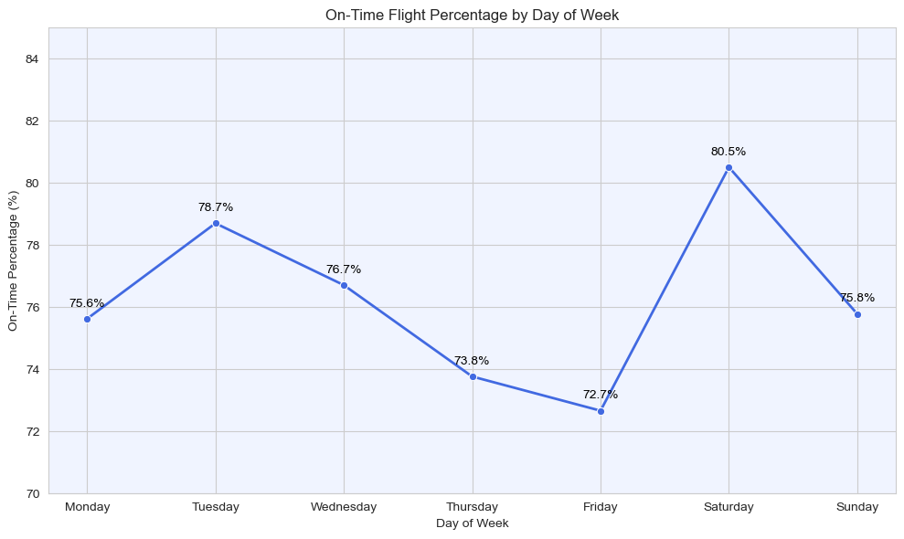

```python
plt.figure(figsize=(10, 6))
sns.set_style("whitegrid")
sns.lineplot(data=day_ontime, x='dayname', y='ontimepercentage', marker='o', linewidth=2, color='royalblue')

# Add data labels on each point
for i, row in day_ontime.iterrows():
    plt.text(row['dayname'], row['ontimepercentage'] + 0.3, f"{row['ontimepercentage']:.1f}%",
             ha='center', va='bottom', fontsize=10, color='black')

# Customize background color
plt.gca().set_facecolor('#f0f4ff')  # Light blue background
plt.title('On-Time Flight Percentage by Day of Week')
plt.ylabel('On-Time Percentage (%)')
plt.xlabel('Day of Week')
plt.ylim(70, 85)  # Adjust range as needed
plt.grid(True)
plt.tight_layout()
plt.show()
```

Based on the graph above, it clearly shows the weekly pattern. The average on-time flight percentage is **highest on Saturday** at 80.5%, followed by Tuesday. The performance then begins to decline, reaching its **lowest point on Friday** with only 72.7% of flights being on time. The most likely reason for this trend is passenger volume; Friday is typically the busiest travel day, with a high number of business and leisure travelers, which places significant stress on airline operations. The graph also suggested that Saturday is a less busy day as higher on-time flight percentage is observed. This could be the result of less passenger that result in greater efficiency. For passenger who want to reduce risk of flight cancellation, Saturday may suggest a good day to book a flight.

### During which months or seasons are flights most likely to be on time?

```python
query3 = """
SELECT
  Month,
  COUNT(*) AS TotalFlights,
  SUM(CASE WHEN ArrDelay <= 15 THEN 1 ELSE 0 END) AS OnTimeFlights,
  (CAST(SUM(CASE WHEN ArrDelay <= 15 THEN 1 ELSE 0 END) AS DOUBLE) / COUNT(*)) * 100 AS OnTimePercentage
FROM flight_data
WHERE Cancelled = 0 AND Diverted = 0 AND ArrDelay IS NOT NULL
GROUP BY Month
ORDER BY CAST(Month AS INT)

"""
month_ontime = pd.read_sql(query3, conn)
month_ontime
```

|  | month | totalflights | ontimeflights | ontimepercentage |
| --- | --- | --- | --- | --- |
| 0 | 1 | 604582 | 460285 | 76.132766 |
| 1 | 2 | 538878 | 386126 | 71.653695 |
| 2 | 3 | 621057 | 474199 | 76.353539 |
| 3 | 4 | 602317 | 470846 | 78.172457 |
| 4 | 5 | 623326 | 497603 | 79.830297 |
| 5 | 6 | 609838 | 434541 | 71.255153 |
| 6 | 7 | 632904 | 458847 | 72.498673 |
| 7 | 8 | 638883 | 474107 | 74.208736 |
| 8 | 9 | 592718 | 494886 | 83.494343 |
| 9 | 10 | 621665 | 498331 | 80.160697 |
| 10 | 11 | 597989 | 489179 | 81.804013 |
| 11 | 12 | 591131 | 401709 | 67.956003 |

```python
#mapping month name
month_map = {
    '1': 'Jan', '2': 'Feb', '3': 'Mar', '4': 'Apr',
    '5': 'May', '6': 'Jun', '7': 'Jul', '8': 'Aug',
    '9': 'Sep', '10': 'Oct', '11': 'Nov', '12': 'Dec'
}
month_order = ['Jan','Feb','Mar','Apr','May','Jun','Jul','Aug','Sep','Oct','Nov','Dec']

#mapping for season
season_map = {
    '1': 'Winter', '2': 'Winter', '3': 'Spring',
    '4': 'Spring', '5': 'Spring', '6': 'Summer',
    '7': 'Summer', '8': 'Summer', '9': 'Fall',
    '10': 'Fall', '11': 'Fall', '12': 'Winter'
}

month_ontime['MonthName'] = month_ontime['month'].map(month_map)
month_ontime['Season'] = month_ontime['month'].map(season_map)
month_ontime['MonthName'] = pd.Categorical(month_ontime['MonthName'], categories=month_order, ordered=True)
month_ontime = month_ontime.sort_values('MonthName')

#to assign colour based on seasons
season_colors = {
    'Winter': '#66c2a5',
    'Spring': '#8da0cb',
    'Summer': '#fc8d62',
    'Fall': '#e78ac3'
}

month_ontime['Color'] = month_ontime['Season'].map(season_colors)
```

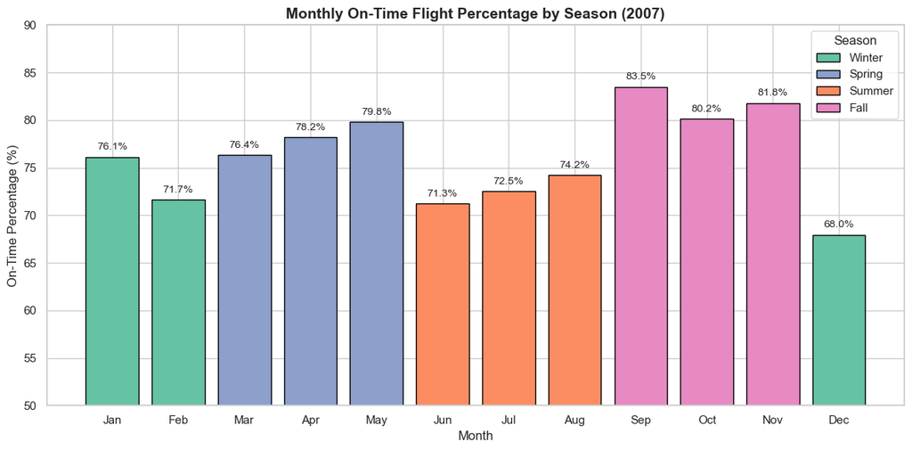

```python
# Plot
plt.figure(figsize=(12, 6))
sns.set(style="whitegrid")

bars = plt.bar(
    month_ontime['MonthName'],
    month_ontime['ontimepercentage'],
    color=month_ontime['Color'],
    edgecolor='black'
)

# Add data labels
for i, row in month_ontime.iterrows():
    plt.text(i, row['ontimepercentage'] + 0.5, f"{row['ontimepercentage']:.1f}%",
             ha='center', va='bottom', fontsize=10)

# Add legend manually
from matplotlib.patches import Patch
legend_elements = [
    Patch(facecolor=color, edgecolor='black', label=season)
    for season, color in season_colors.items()
]
plt.legend(handles=legend_elements, title='Season')

# Customize plot
plt.title('Monthly On-Time Flight Percentage by Season (2007)', fontsize=14, weight='bold')
plt.ylabel('On-Time Percentage (%)')
plt.xlabel('Month')
plt.ylim(50, 90)
plt.tight_layout()
plt.show()
```

Now, we want to observe on-time flight performance in relation to the seasons. The performance can be influenced by the weather and travel demand, and the graph above shows a clear seasonal pattern. The **fall** season (September-November) generally shows the **highest** on-time flight percentage. This is largely due to favorable weather conditions, as cooler temperatures in fall season can lower density altitude. This factor can positvely influence the aircraft performance and thunderstorm activity. Additionally, the fall is considered a "shoulder season," meaning there is reduced demand for air travel between the busy summer and holiday periods. As a result, fewer flights and less crowded skies during fall can improve operational efficiency and minimize flight delays.

In contrast, **winter months (December-February)**, particularly December, show the lowest on-time flight performance. Severe weather conditions like snow and ice can force temporary runway closures and significantly delay flights. Furthermore, December is a holiday month, so certain routes and destinations experience high demand, leading to compounding effect on flight performance. The delays in winter are often attributed to surface winds, low ceilings, and poor visibility.

**Summer (June-August)** on-time performance also sees a decline, which driven by two key factors: increased demand and extreme heat. Summer is a peak travel season with a higher volume of flights and crowded airports, which naturally leads to more delays. Extreme heat further complicates matters by lowering air density. When air density is reduced, it can negatively impact aircraft performance by decreasing wing lift and engine thrust. This factor may necessitate a reduction in the aircraft's weight or a delay in departure that can reduce plane takeoff and landing efficiency.

## ⏱️ Delay Factors

There are five delay factors recorded in the data, which are:

1. **Carrier Delay** - These are delays that are directly attributable to the airline's own operations including aircraft maintenance issues and aircraft cleaning.
2. **Weather Delay** - These are delays caused by actual or forecasted adverse meteorological conditions that prevent safe operation.
3. **National Air System (NAS) Delay** - These are delays attributable to the broader air traffic control system and infrastructure like airport congestion.
4. **Security Delay** - These are delays caused directly by security measures or incidents, such as increased security screenings or security breaches or threats.
5. **Late Arriving Aircraft Delay** - This is a cascading delay, meaning the current flight is delayed because the previous flight that was supposed to use this particular aircraft arrived late.

### Identify and rank the top factors contributing to flight delays, based on the delay categories provided in the dataset, and quantify the impact of each factor (in minutes of delay and percentage of total delays)

```python
query4b = """

SELECT
  SUM(CarrierDelay) AS CarrierDelay,
  COUNT(CASE WHEN CarrierDelay > 0 THEN 1 END) AS CarrierCount,

  SUM(WeatherDelay) AS WeatherDelay,
  COUNT(CASE WHEN WeatherDelay > 0 THEN 1 END) AS WeatherCount,

  SUM(NASDelay) AS NASDelay,
  COUNT(CASE WHEN NASDelay > 0 THEN 1 END) AS NASCount,

  SUM(SecurityDelay) AS SecurityDelay,
  COUNT(CASE WHEN SecurityDelay > 0 THEN 1 END) AS SecurityCount,

  SUM(LateAircraftDelay) AS LateAircraftDelay,
  COUNT(CASE WHEN LateAircraftDelay > 0 THEN 1 END) AS LateAircraftCount
FROM flight_data
WHERE Cancelled = 0 AND Diverted = 0


"""

df = pd.read_sql(query4b, conn)
df
```

|  | carrierdelay | carriercount | weatherdelay | weathercount | nasdelay | nascount | securitydelay | securitycount | lateaircraftdelay | lateaircraftcount |
| --- | --- | --- | --- | --- | --- | --- | --- | --- | --- | --- |
| 0 | 28808434 | 814922 | 5739649 | 127849 | 28200746 | 1044257 | 176906 | 9269 | 38004942 | 838599 |

```python
# to melt into long format
delayfactors2 = pd.DataFrame({
    'Factor': ['Carrier', 'Weather', 'NAS', 'Security', 'LateAircraft'],
    'TotalDelay': [
        df['carrierdelay'][0],
        df['weatherdelay'][0],
        df['nasdelay'][0],
        df['securitydelay'][0],
        df['lateaircraftdelay'][0]
    ],
    'Count': [
        df['carriercount'][0],
        df['weathercount'][0],
        df['nascount'][0],
        df['securitycount'][0],
        df['lateaircraftcount'][0]
    ]
})

# calculate average delay and percentage
delayfactors2['AverageDelay'] = (delayfactors2['TotalDelay'] / delayfactors2['Count']).round(2)
delayfactors2['Percentage'] = round((delayfactors2['TotalDelay'] / delayfactors2['TotalDelay'].sum()) * 100, 2)

# Optional: pretty factor names (if needed)
factor_map = {
    'Carrier': 'Carrier Delay',
    'Weather': 'Weather Delay',
    'NAS': 'Air Traffic (NAS)',
    'Security': 'Security Delay',
    'LateAircraft': 'Late Aircraft'
}
delayfactors2['FactorName'] = delayfactors2['Factor'].map(factor_map)
delayfactors2
```

|  | Factor | TotalDelay | Count | AverageDelay | Percentage | FactorName |
| --- | --- | --- | --- | --- | --- | --- |
| 0 | Carrier | 28808434 | 814922 | 35.35 | 28.54 | Carrier Delay |
| 1 | Weather | 5739649 | 127849 | 44.89 | 5.69 | Weather Delay |
| 2 | NAS | 28200746 | 1044257 | 27.01 | 27.94 | Air Traffic (NAS) |
| 3 | Security | 176906 | 9269 | 19.09 | 0.18 | Security Delay |
| 4 | LateAircraft | 38004942 | 838599 | 45.32 | 37.65 | Late Aircraft |

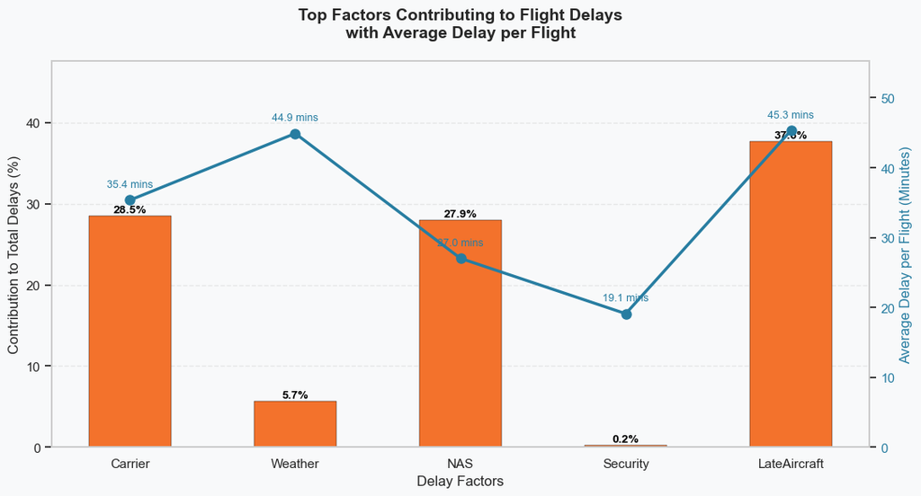

```python
# Set seaborn style
sns.set_theme(style='whitegrid')
plt.rcParams.update({
    'font.family': 'sans-serif',
    'font.size': 11
})

fig, ax1 = plt.subplots(figsize=(11, 6))
ax2 = ax1.twinx()

# colour
bar_color = '#F3722C'       # warm coral
line_color = '#277DA1'      # navy blue
bg_color = '#F8F9FA'        # light background

# apply bg colour
ax1.set_facecolor(bg_color)
fig.patch.set_facecolor(bg_color)

# Bar plot= % of total delays
bars = ax1.bar(
    delayfactors2['Factor'],
    delayfactors2['Percentage'],
    color=bar_color,
    width=0.5,
    edgecolor='black',
    linewidth=0.3
)

# data label for percentage
for i, row in delayfactors2.iterrows():
    ax1.text(
        i, row['Percentage'] + 0.1,
        f"{row['Percentage']:.1f}%",
        ha='center', va='bottom',
        fontsize=10, fontweight='bold', color='black'
    )

# Line plot: Average delay
ax2.plot(
    delayfactors2['Factor'],
    delayfactors2['AverageDelay'],
    color=line_color,
    marker='o',
    linewidth=2.5,
    markersize=8,
    label='Avg Delay (min)'
)

# Add average delay labels to line points
for i, row in delayfactors2.iterrows():
    ax2.text(
        i, row['AverageDelay'] + 1.5,
        f"{row['AverageDelay']:.1f} mins",
        ha='center', va='bottom',
        fontsize=9, color=line_color
    )

# Axis labels and styling
ax1.set_ylabel('Contribution to Total Delays (%)', fontsize=12)
ax1.set_xlabel('Delay Factors', fontsize=12)
ax2.set_ylabel('Average Delay per Flight (Minutes)', fontsize=12, color=line_color)
ax2.tick_params(axis='y', labelcolor=line_color)

# Title and layout
plt.title('Top Factors Contributing to Flight Delays\nwith Average Delay per Flight', fontsize=14, weight='bold', pad=20)

# Grid and axis limits
ax1.set_ylim(0, delayfactors2['Percentage'].max() + 10)
ax2.set_ylim(0, delayfactors2['AverageDelay'].max() + 10)
ax1.grid(True, which='major', axis='y', linestyle='--', alpha=0.4)
ax1.grid(False, axis='x')
ax2.grid(False)

plt.tight_layout()
plt.show()
```

From the graph above, we can observe that te most significant factors contributing to flight delays are **Late Arriving Aircraft**, **Carrier** Delays, and **NAS (National Air System)** delays, which account for the majority of recorded incidents.

## ⛈️ Cancellation Analysis:

Earlier, we explored the reasons behind flight delays. Now, let’s shift our focus to why flights get cancelled. According to the data, the reasons of flight cancellations are categorised into four codes:

- **A – Carrier-related** issues: Problems caused directly by the airline, such as crew shortages or mechanical issues.
- **B – Weather**: Severe weather conditions that make flying unsafe.
- **C – National Aviation System (NAS)**: Issues like air traffic control delays or system inefficiencies.
- **D – Security**: Cancellations due to security threats or mandatory precautions.

### Which of these is the most common reason for flight cancellations.

```python
query5 = """

SELECT
  CASE CancellationCode
    WHEN 'A' THEN 'Carrier'
    WHEN 'B' THEN 'Weather'
    WHEN 'C' THEN 'NAS'
    WHEN 'D' THEN 'Security'
  END AS CancellationReason,
  COUNT(*) AS CancelledFlights
FROM flight_data
WHERE Cancelled = '1'
GROUP BY CancellationCode
ORDER BY CancelledFlights DESC

"""

cancel_df = pd.read_sql(query5, conn)
cancel_df
```

|  | cancellationreason | cancelledflights |
| --- | --- | --- |
| 0 | Carrier | 66779 |
| 1 | Weather | 61935 |
| 2 | NAS | 31995 |
| 3 | Security | 39 |

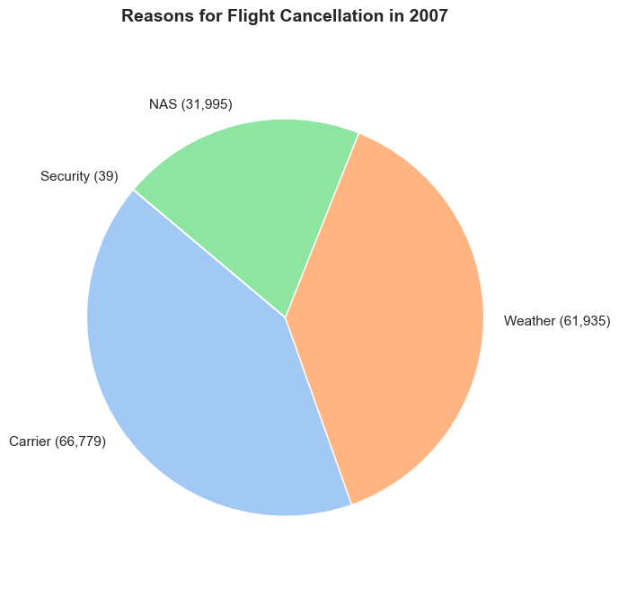

```python
## plot pie chart

plt.figure(figsize=(7,7))
colours = sns.color_palette('pastel')

#label

labels = [
    f"{reason} ({count:,})"
    for reason, count in zip(cancel_df['cancellationreason'], cancel_df['cancelledflights'])
]

plt.pie(
    cancel_df['cancelledflights'],
    labels=labels,
    startangle=140,
    autopct=None,
    colors=colours,
    wedgeprops=dict(edgecolor='white'),
    pctdistance=0.8
)

plt.title('Reasons for Flight Cancellation in 2007', fontsize=14, weight='bold')
plt.axis('equal')
plt.tight_layout()
plt.show()
```

From the pie chart, we observe that **most flight cancellations** were due to **Carrier-related issues (A)** and **Weather conditions (B)**. Carrier-related cancellations often stem from internal airline issues, such as scheduling conflicts, low passenger demand on certain routes, aircraft maintenance, technical faults or operational challenges. For example, if a particular flight has consistently low ticket sales, the airline might cancel it to reduce losses. Or, if a plane is grounded due to a technical inspection, the airline may not have a backup ready—leading to a cancellation.

Weather (Code B) is a natural and uncontrollable factor, and it's reasonable to see it as a major cause. Thunderstorms, heavy rainfall, snow, strong winds, or low visibility pose safety risks. Cancelling flights under such conditions is often necessary to protect passengers and crew. **National Aviation System (Code C) related issues come third** in frequency. These can includes air traffic control delays, airport congestion, runway closures, system malfunctions or disruptions. These are often infrastructure-related delays beyond the airline’s control.

**Security-related (Code D) cancellations are rare**, with only 39 recorded instances. These may involve threats, suspicious activity, or mandatory government interventions. While rare, these events are treated with the highest priority due to their potential risk.

### Correlation between cancellations and specific airlines, airports, or time periods. Is there any patterns identified?

#### Airlines

Here we want to view which airlines are associated with most cancellation rate.

```python
query6 = """

SELECT
  f.UniqueCarrier AS AirlineCode,
  c.Description AS AirlineName,
  COUNT(*) AS TotalFlights,
  SUM(CASE WHEN f.Cancelled = '1' THEN 1 ELSE 0 END) AS CancelledFlights,
  ROUND(
    (CAST(SUM(CASE WHEN f.Cancelled = '1' THEN 1 ELSE 0 END) AS DOUBLE) / COUNT(*)) * 100,
    2
  ) AS CancelledPercentage
FROM flight_data f
JOIN carriers c
  ON f.UniqueCarrier = c.Code
GROUP BY f.UniqueCarrier, c.Description
ORDER BY CancelledPercentage DESC
LIMIT 10

"""

cancel_airlines = pd.read_sql(query6, conn)
cancel_airlines
```

|  | airlinecode | airlinename | totalflights | cancelledflights | cancelledpercentage |
| --- | --- | --- | --- | --- | --- |
| 0 | MQ | American Eagle Airlines Inc. | 540494 | 22792 | 4.22 |
| 1 | YV | Mesa Airlines Inc. | 294362 | 11287 | 3.83 |
| 2 | OH | Comair Inc. | 233787 | 8851 | 3.79 |
| 3 | EV | Atlantic Southeast Airlines | 286234 | 8920 | 3.12 |
| 4 | 9E | Pinnacle Airlines Inc. | 258851 | 7939 | 3.07 |
| 5 | AA | American Airlines Inc. | 633857 | 17924 | 2.83 |
| 6 | XE | Expressjet Airlines Inc. | 434773 | 10800 | 2.48 |
| 7 | UA | United Air Lines Inc. | 490002 | 11929 | 2.43 |
| 8 | OO | Skywest Airlines Inc. | 597882 | 14186 | 2.37 |
| 9 | B6 | JetBlue Airways | 191450 | 3710 | 1.94 |

[figure not shown]

```python
# creating a visualisation


plt.figure(figsize = (10,8))
bar_plot = sns.barplot(x = 'cancelledpercentage', y = 'airlinename', data = cancel_airlines, color = "#589FF5")


for index, value in enumerate(cancel_airlines['cancelledpercentage']):
    bar_plot.text(value, index, f' {value}%')


plt.title('Top 9 Airlines by Cancellation Percentage', fontsize=16)
plt.xlabel('Cancellation Percentage (%)', fontsize=12)
plt.ylabel('Airline Name', fontsize=12)

# Ensure the layout is tight
plt.tight_layout()

# Save the plot to a file
plt.savefig('top_airlines_cancellation_plot.png')
```

The data shows that the **top airlines with overall high cancellation rates** are:

1. American Eagle Airlines
2. Mesa Airlines
3. Comair Inc.

This indicates that, across all causes, these three carriers contribute significantly to flight disruptions.

To better understand the pattern, let’s look at which airlines are most frequently responsible under each cancellation category.

```python
query7 = """

SELECT
  f.UniqueCarrier AS AirlineCode,
  c.Description AS AirlineName,
  CASE f.CancellationCode
    WHEN 'A' THEN 'Carrier'
    WHEN 'B' THEN 'Weather'
    WHEN 'C' THEN 'NAS'
    WHEN 'D' THEN 'Security'
    ELSE 'Unknown'
  END AS CancellationReason,
  COUNT(*) AS CancelCount
FROM flight_data f
JOIN carriers c
  ON f.UniqueCarrier = c.Code
WHERE f.Cancelled = '1'
GROUP BY f.UniqueCarrier, c.Description, f.CancellationCode
ORDER BY CancellationReason, CancelCount DESC



"""
cancel_reason_airline = pd.read_sql(query7, conn)
top3_perreason = (
    cancel_reason_airline
    .sort_values(['cancellationreason', 'cancelcount'], ascending=[True, False])
    .groupby('cancellationreason')
    .head(3)
    .reset_index(drop=True)

)

top3_perreason
```

|  | airlinecode | airlinename | cancellationreason | cancelcount |
| --- | --- | --- | --- | --- |
| 0 | UA | United Air Lines Inc. | Carrier | 7348 |
| 1 | WN | Southwest Airlines Co. | Carrier | 5760 |
| 2 | US | US Airways Inc. (Merged with America West 9/05... | Carrier | 5594 |
| 3 | MQ | American Eagle Airlines Inc. | NAS | 5982 |
| 4 | XE | Expressjet Airlines Inc. | NAS | 5468 |
| 5 | OO | Skywest Airlines Inc. | NAS | 4889 |
| 6 | WN | Southwest Airlines Co. | Security | 16 |
| 7 | OH | Comair Inc. | Security | 13 |
| 8 | OO | Skywest Airlines Inc. | Security | 8 |
| 9 | MQ | American Eagle Airlines Inc. | Weather | 11732 |
| 10 | AA | American Airlines Inc. | Weather | 8714 |
| 11 | OH | Comair Inc. | Weather | 6297 |

```python
# rename US Airways by airline code
top3_perreason['airlinename'] = top3_perreason['airlinename'].replace(
    "US Airways Inc. (Merged with America West 9/05. Reporting for both starting 10/07.)",
    "US Airways Inc."
)
```

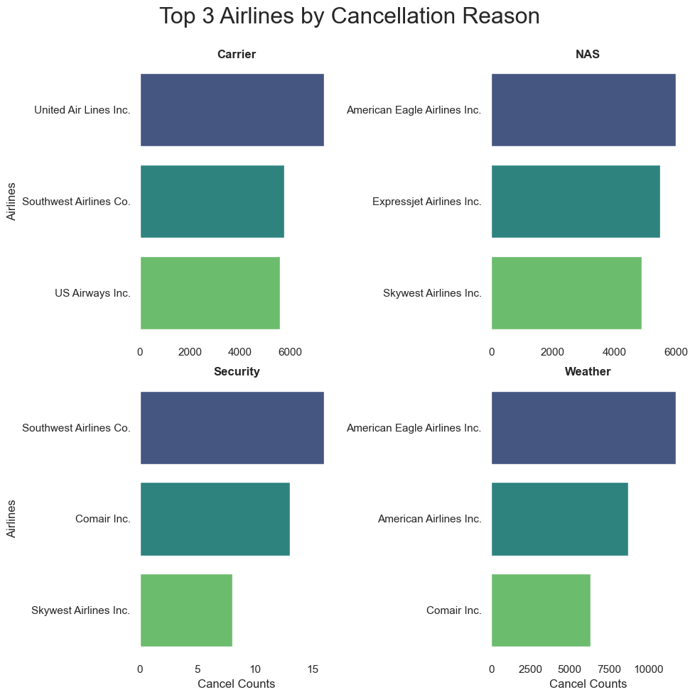

```python
sns.set_theme(style=None)

plotsub= sns.FacetGrid(top3_perreason,
    col='cancellationreason',
    col_wrap=2,
    height=5,
    sharex=False,
    sharey=False
)

plotsub.map_dataframe(
    sns.barplot,
    x='cancelcount',
    y='airlinename',
    palette='viridis'
)


##to remove white grid,


# Disable grid, background color, and all spines
for ax in plotsub.axes.flatten():
    ax.grid(False)                          # turn off grid
    ax.set_facecolor("white")               # white background
    for spine in ax.spines.values():
        spine.set_visible(False)

plotsub.set_axis_labels("Cancel Counts", "Airlines")
plotsub.set_titles(col_template="{col_name}", fontweight = 'bold')
plotsub.fig.subplots_adjust(top=0.9)
plotsub.fig.suptitle("Top 3 Airlines by Cancellation Reason", fontsize=23)
# plt.tight_layout()
plt.show()
```

The plot illustrates the top three airlines most frequently cancelling flights for each cancellation reason, offering a clearer view into which carriers are most affected by specific issues. For **carrier-related cancellations**, the highest contributors are United Airlines, Southwest Airlines, and US Airways. These cancellations are typically caused by internal operational problems such as crew shortages, technical faults, or scheduling conflicts—factors generally within the airline's control.

For **weather-related cancellations**, American Eagle Airlines, American Airlines, and Comair Inc. top the list. Although weather is beyond an airline’s control, the high number of cancellations for these carriers may indicate they operate more frequently in regions prone to severe weather, or they have limited capacity to respond to disruptions, such as fewer standby aircraft or flexible rerouting options.

In the category of **NAS cancellations** which includes air traffic control issues, airport congestion, and system-related delays—the leading airlines are American Eagle Airlines, ExpressJet Airlines, and SkyWest Airlines. Their frequent appearance here suggests that they may serve routes involving busy or congested airports or fly more often during high-traffic periods

Lastly, for the less common **security-related cancellations**, Southwest Airlines, Comair Inc., and SkyWest Airlines appear most frequently. While these cases are rare, they likely involve serious incidents such as threats, evacuations, or airport-level disruptions that mandate immediate flight cancellations.

**American Eagle Airlines** appears in three categories: Weather, NAS, and Overall., with high overall cancellation rate and frequently affected by external and internal issues.

### Month

```python
query10 = """

SELECT
  f.Month,
  COUNT(*) AS TotalFlights,
  SUM(CASE WHEN f.Cancelled = '1' THEN 1 ELSE 0 END) AS CancelledFlights,
  ROUND(
    (CAST(SUM(CASE WHEN f.Cancelled = '1' THEN 1 ELSE 0 END) AS DOUBLE) / COUNT(*)) * 100,
    2
  ) AS CancelledPercentage
FROM Flight_Data f
WHERE
  f.Year = '2007'
GROUP BY
  f.Month
ORDER BY
  f.Month

"""
cancel_month = pd.read_sql(query10, conn)
cancel_month

#to sort accordingly
df = cancel_month
month_map = {
    '1': 'Jan', '2': 'Feb', '3': 'Mar', '4': 'Apr',
    '5': 'May', '6': 'Jun', '7': 'Jul', '8': 'Aug',
    '9': 'Sep', '10': 'Oct', '11': 'Nov', '12': 'Dec'
}
month_order = ['Jan','Feb','Mar','Apr','May','Jun','Jul','Aug','Sep','Oct','Nov','Dec']

df['month_name'] = df['f.month'].map(month_map)
df['month_name'] = pd.Categorical(df['month_name'], categories=month_order, ordered=True)
df = df.sort_values('month_name')
df
```

|  | f.month | totalflights | cancelledflights | cancelledpercentage | month_name |
| --- | --- | --- | --- | --- | --- |
| 0 | 1 | 621559 | 15777 | 2.54 | Jan |
| 4 | 2 | 565604 | 25465 | 4.50 | Feb |
| 5 | 3 | 639209 | 16877 | 2.64 | Mar |
| 6 | 4 | 614648 | 11138 | 1.81 | Apr |
| 7 | 5 | 631609 | 6841 | 1.08 | May |
| 8 | 6 | 629280 | 17243 | 2.74 | Jun |
| 9 | 7 | 648560 | 13506 | 2.08 | Jul |
| 10 | 8 | 653279 | 12295 | 1.88 | Aug |
| 11 | 9 | 600187 | 6507 | 1.08 | Sep |
| 1 | 10 | 629992 | 7327 | 1.16 | Oct |
| 2 | 11 | 605149 | 6279 | 1.04 | Nov |
| 3 | 12 | 614139 | 21493 | 3.50 | Dec |

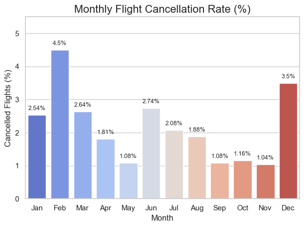

```python
#create a visualisation

plot = sns.barplot(x='month_name', y='cancelledpercentage', data=df, palette="coolwarm", hue = "month_name")

# for labels
for i, row in enumerate(df.itertuples()):
    plt.text(i, row.cancelledpercentage + 0.1, f"{row.cancelledpercentage}%", ha='center', va='bottom', fontsize=9)

plt.title("Monthly Flight Cancellation Rate (%)", fontsize=16)
plt.xlabel("Month")
plt.ylabel("Cancelled Flights (%)")
plt.ylim(0, max(df['cancelledpercentage']) + 1)

plt.tight_layout()
plt.show()
```

The analysis of flight cancellations by month reveals notable seasonal patterns. **February** has the **highest** cancellation rate at 4.50%, followed by **December at 3.50%**, and June and March with rates slightly above 2.5%. These peaks may correspond to periods of unpredictable weather, such as winter storms or summer thunderstorms, and high travel demand that increases operational pressure. In contrast, months like **November (1.04%), May (1.08%), and September (1.08%**) show the **lowest cancellation** percentages, suggesting more stable flight operations during these times. Overall, cancellations appear to be seasonally influenced, with increased disruptions during winter and mid-year months, likely due to a combination of weather-related factors and holiday travel surges.

```python
warnings.filterwarnings("ignore", category=UserWarning) #to exclude warnings

query9 = """

WITH origin_stats AS (
    SELECT
        Origin AS AirportCode,
        SUM(CASE WHEN Cancelled = '1' THEN 1 ELSE 0 END) AS Origin_Cancelled_Flights,
        COUNT(*) AS Origin_Total_Flights
    FROM Flight_Data
    GROUP BY Origin
),
dest_stats AS (
    SELECT
        Dest AS AirportCode,
        SUM(CASE WHEN Cancelled = '1' THEN 1 ELSE 0 END) AS Dest_Cancelled_Flights,
        COUNT(*) AS Dest_Total_Flights
    FROM Flight_Data
    GROUP BY Dest
)
SELECT
    COALESCE(o.AirportCode, d.AirportCode) AS AirportCode,
    a.airport AS AirportName,
    a.city AS City,
    a.state AS State,
    a.country AS Country,
    o.Origin_Cancelled_Flights,
    o.Origin_Total_Flights,
    ROUND(
        (CAST(o.Origin_Cancelled_Flights AS DOUBLE) / o.Origin_Total_Flights) * 100, 2
    ) AS Origin_Cancellation_Rate,
    d.Dest_Cancelled_Flights,
    d.Dest_Total_Flights,
    ROUND(
        (CAST(d.Dest_Cancelled_Flights AS DOUBLE) / d.Dest_Total_Flights) * 100, 2
    ) AS Dest_Cancellation_Rate
FROM origin_stats o
FULL OUTER JOIN dest_stats d ON o.AirportCode = d.AirportCode
LEFT JOIN Airports a ON COALESCE(o.AirportCode, d.AirportCode) = a.iata
ORDER BY Origin_Cancellation_Rate DESC, Dest_Cancellation_Rate DESC

"""
cancel_airportsdf = pd.read_sql(query9, conn)
cancel_airportsdf
```

|  | airportcode | airportname | city | state | country | o.origin_cancelled_flights | o.origin_total_flights | origin_cancellation_rate | d.dest_cancelled_flights | d.dest_total_flights | dest_cancellation_rate |
| --- | --- | --- | --- | --- | --- | --- | --- | --- | --- | --- | --- |
| 0 | TEX | Telluride Regional | Telluride | CO | USA | 32.0 | 216.0 | 14.81 | 22 | 216 | 10.19 |
| 1 | ACK | Nantucket Memorial | Nantucket | MA | USA | 37.0 | 314.0 | 11.78 | 37 | 319 | 11.60 |
| 2 | ALO | Waterloo Municipal | Waterloo | IA | USA | 34.0 | 300.0 | 11.33 | 32 | 302 | 10.60 |
| 3 | SUX | Sioux Gateway | Sioux City | IA | USA | 60.0 | 534.0 | 11.24 | 54 | 535 | 10.09 |
| 4 | ISO | Kinston Regional Jetport At Stallin | Kinston | NC | USA | 1.0 | 9.0 | 11.11 | 1 | 8 | 12.50 |
| ... | ... | ... | ... | ... | ... | ... | ... | ... | ... | ... | ... |
| 305 | BFF | Scotts Bluff County | Scottsbluff | NE | USA | NaN | NaN | NaN | 0 | 1 | 0.00 |
| 306 | OGD | Ogden-Hinckley | Ogden | UT | USA | NaN | NaN | NaN | 0 | 5 | 0.00 |
| 307 | PVU | Provo Muni | Provo | UT | USA | NaN | NaN | NaN | 0 | 4 | 0.00 |
| 308 | CYS | Cheyenne | Cheyenne | WY | USA | NaN | NaN | NaN | 0 | 6 | 0.00 |
| 309 | PUB | Pueblo Memorial | Pueblo | CO | USA | NaN | NaN | NaN | 0 | 2 | 0.00 |

310 rows × 11 columns

```python
cancel_airportsdf.head(13)
```

|  | airportcode | airportname | city | state | country | o.origin_cancelled_flights | o.origin_total_flights | origin_cancellation_rate | d.dest_cancelled_flights | d.dest_total_flights | dest_cancellation_rate |
| --- | --- | --- | --- | --- | --- | --- | --- | --- | --- | --- | --- |
| 0 | TEX | Telluride Regional | Telluride | CO | USA | 32.0 | 216.0 | 14.81 | 22 | 216 | 10.19 |
| 1 | ACK | Nantucket Memorial | Nantucket | MA | USA | 37.0 | 314.0 | 11.78 | 37 | 319 | 11.60 |
| 2 | ALO | Waterloo Municipal | Waterloo | IA | USA | 34.0 | 300.0 | 11.33 | 32 | 302 | 10.60 |
| 3 | SUX | Sioux Gateway | Sioux City | IA | USA | 60.0 | 534.0 | 11.24 | 54 | 535 | 10.09 |
| 4 | ISO | Kinston Regional Jetport At Stallin | Kinston | NC | USA | 1.0 | 9.0 | 11.11 | 1 | 8 | 12.50 |
| 5 | BJI | Bemidji-Beltrami County | Bemidji | MN | USA | 14.0 | 128.0 | 10.94 | 13 | 128 | 10.16 |
| 6 | ASE | Aspen-Pitkin Co/Sardy | Aspen | CO | USA | 556.0 | 5305.0 | 10.48 | 484 | 5250 | 9.22 |
| 7 | INL | Falls International | International Falls | MN | USA | 22.0 | 218.0 | 10.09 | 20 | 218 | 9.17 |
| 8 | RHI | Rhinelander-Oneida County | Rhinelander | WI | USA | 20.0 | 223.0 | 8.97 | 20 | 223 | 8.97 |
| 9 | EAU | Chippewa Valley Regional | Eau Claire | WI | USA | 6.0 | 72.0 | 8.33 | 7 | 73 | 9.59 |
| 10 | ADQ | Kodiak | Kodiak | AK | USA | 57.0 | 691.0 | 8.25 | 56 | 691 | 8.10 |
| 11 | SPI | Capital | Springfield | IL | USA | 134.0 | 1745.0 | 7.68 | 116 | 1742 | 6.66 |
| 12 | AZO | Kalamazoo County | Kalamazoo | MI | USA | 375.0 | 5121.0 | 7.32 | 348 | 5108 | 6.81 |

```python
#visualisation

cancel_airports_origin = cancel_airportsdf.sort_values('origin_cancellation_rate', ascending = False)
```

## ⚠️ Problematic Route

To understand the reliability of air travel, it is important to identify poorly performing flight routes. A poorly performing route is typically characterized by a high cancellation rate, frequent delays, and persistent issues across time, even outside of peak travel periods or holidays.

In this part, we want to identify specific routes (origin-destination pairs) that show consistently poor performance, and analyse the reasons these particular flights are prone to cancellations or delays.

#### Problematic Route by Cancellation Rate

```python
query8 = """

SELECT
    CONCAT(f.Origin, ' - ', f.Dest) AS route,
    a_origin.airport AS OriginAirportName,
    a_dest.airport AS DestAirportName,
    COUNT(*) AS total_flights,
    SUM(CASE WHEN f.Cancelled = '1' THEN 1 ELSE 0 END) AS cancelled_flights,
    ROUND(
        (CAST(SUM(CASE WHEN f.Cancelled = '1' THEN 1 ELSE 0 END) AS DOUBLE) / COUNT(*)) * 100, 2
    ) AS cancellation_rate
FROM
    Flight_Data f
LEFT JOIN
    Airports a_origin ON f.Origin = a_origin.iata
LEFT JOIN
    Airports a_dest ON f.Dest = a_dest.iata
GROUP BY
    f.Origin, f.Dest, a_origin.airport, a_dest.airport
HAVING
    COUNT(*) >= 250 -- Adjust this number to focus on high-volume routes
ORDER BY
    cancellation_rate DESC
LIMIT 20

"""

route_airports = pd.read_sql(query8, conn)
route_airports
```

|  | route | originairportname | destairportname | total_flights | cancelled_flights | cancellation_rate |
| --- | --- | --- | --- | --- | --- | --- |
| 0 | LGA - LEX | LaGuardia | Blue Grass | 322 | 43 | 13.35 |
| 1 | ALO - MSP | Waterloo Municipal | Minneapolis-St Paul Intl | 300 | 34 | 11.33 |
| 2 | SUX - MSP | Sioux Gateway | Minneapolis-St Paul Intl | 534 | 60 | 11.24 |
| 3 | CAE - EWR | Columbia Metropolitan | Newark Intl | 721 | 80 | 11.10 |
| 4 | LGA - TYS | LaGuardia | McGhee-Tyson | 559 | 62 | 11.09 |
| 5 | ASE - ORD | Aspen-Pitkin Co/Sardy | Chicago O'Hare International | 252 | 27 | 10.71 |
| 6 | ASE - DEN | Aspen-Pitkin Co/Sardy | Denver Intl | 3793 | 402 | 10.60 |
| 7 | MSP - ALO | Minneapolis-St Paul Intl | Waterloo Municipal | 302 | 32 | 10.60 |
| 8 | EWR - CAE | Newark Intl | Columbia Metropolitan | 720 | 76 | 10.56 |
| 9 | LGA - GSP | LaGuardia | Greenville-Spartanburg | 615 | 63 | 10.24 |
| 10 | MSP - SUX | Minneapolis-St Paul Intl | Sioux Gateway | 534 | 54 | 10.11 |
| 11 | LGA - GRR | LaGuardia | Kent County International | 608 | 61 | 10.03 |
| 12 | JFK - ORF | John F Kennedy Intl | Norfolk International | 406 | 40 | 9.85 |
| 13 | LAN - ORD | Capital City | Chicago O'Hare International | 1650 | 162 | 9.82 |
| 14 | DEN - ASE | Denver Intl | Aspen-Pitkin Co/Sardy | 3779 | 363 | 9.61 |
| 15 | AZO - ORD | Kalamazoo County | Chicago O'Hare International | 2735 | 262 | 9.58 |
| 16 | IND - LGA | Indianapolis International | LaGuardia | 1313 | 125 | 9.52 |
| 17 | EWR - BWI | Newark Intl | Baltimore-Washington International | 1447 | 137 | 9.47 |
| 18 | BWI - EWR | Baltimore-Washington International | Newark Intl | 1447 | 136 | 9.40 |
| 19 | CLD - PHX | MC Clellan-Palomar Airport | Phoenix Sky Harbor International | 406 | 38 | 9.36 |

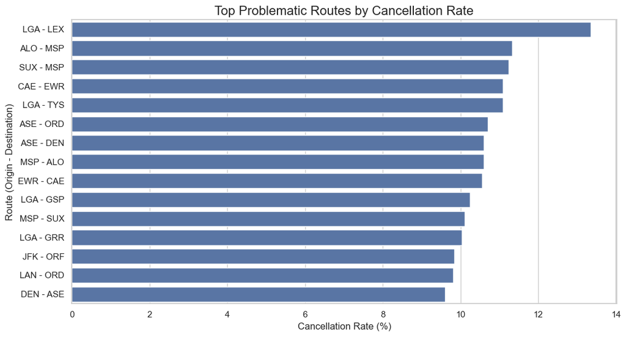

```python
route_airports_top7 = route_airports.head(15)


plt.figure(figsize=(11, 6))
bar_plot = sns.barplot(
    x='cancellation_rate', y='route', data=route_airports_top7
)

# Add a title and labels
plt.title('Top Problematic Routes by Cancellation Rate', fontsize=16)
plt.xlabel('Cancellation Rate (%)', fontsize=12)
plt.ylabel('Route (Origin - Destination)', fontsize=12)

# Ensure the layout is tight and labels are not cut off
plt.tight_layout()

# Display the plot
plt.show()
```

The bar chart reveals that the route from **LaGuardia (LGA) to Blue Grass (LEX)** has the highest cancellation rate at 13.35%, which is significantly above average. One likely explanation is that Blue Grass Airport, being a small regional airport in eastern Kentucky, may experience lower passenger demand, making it less profitable and more vulnerable to cancellation when operational issues arise. Also the route from **Sioux Gateway Airport (SUX) to Minneapolis-St Paul International (MSP)** shows a high cancellation rate of 11.24%, likely due to Sioux Gateway being a small regional airport with limited infrastructure and flight volume.

Similarly, the route from **Aspen-Pitkin County Airport (ASE)** to **Denver International (DEN)**, as well as the reverse direction (DEN - ASE) shows a prominent cancellation rate despite being a short-haul connection. Aspen-Pitkin County Airport is located in a mountainous region with steep terrain and a short runway making it particularly sensitive to winter weather conditions like snowstorms, wind shear, and low visibility.

Here, we can see that geographical factors are one of the key contributor to flight cancellations on these routes, while passenger demand and operational constraints also play important roles.

#### Problematic Route by Arrival Delays (in minutes)

```python
query11 = """

SELECT
    CONCAT(f.Origin, ' - ', f.Dest) AS route,
    a_origin.airport AS OriginAirportName,
    a_dest.airport AS DestAirportName,
    COUNT(*) AS total_flights,
    ROUND(AVG(f.ArrDelay), 2) AS avg_arrival_delay
FROM
    Flight_Data f
LEFT JOIN
    Airports a_origin ON f.Origin = a_origin.iata
LEFT JOIN
    Airports a_dest ON f.Dest = a_dest.iata
WHERE
    f.Year = '2007'
GROUP BY
    f.Origin, f.Dest, a_origin.airport, a_dest.airport
HAVING
    -- Filter for routes with a significant number of flights
    COUNT(*) >= 250
    -- Filter for routes with an average arrival delay of more than 15 minutes
    AND AVG(f.ArrDelay) > 15
ORDER BY
    avg_arrival_delay DESC
LIMIT 20

"""

prob_route2 = pd.read_sql(query11, conn)
prob_route2
```

|  | route | originairportname | destairportname | total_flights | avg_arrival_delay |
| --- | --- | --- | --- | --- | --- |
| 0 | ASE - ORD | Aspen-Pitkin Co/Sardy | Chicago O'Hare International | 252 | 58.10 |
| 1 | EWR - TUL | Newark Intl | Tulsa International | 339 | 52.31 |
| 2 | LEX - EWR | Blue Grass | Newark Intl | 320 | 50.68 |
| 3 | BGR - EWR | Bangor International | Newark Intl | 432 | 48.94 |
| 4 | EWR - LIT | Newark Intl | Adams | 332 | 48.08 |
| 5 | EWR - BQN | Newark Intl | Rafael Hernandez | 365 | 45.45 |
| 6 | MSN - EWR | Dane County Regional | Newark Intl | 313 | 43.69 |
| 7 | EWR - ABQ | Newark Intl | Albuquerque International | 352 | 43.00 |
| 8 | PHL - PDX | Philadelphia Intl | Portland Intl | 283 | 38.33 |
| 9 | IAD - BHM | Washington Dulles International | Birmingham International | 365 | 38.25 |
| 10 | PHL - ROC | Philadelphia Intl | Greater Rochester Int'l | 264 | 37.61 |
| 11 | EWR - LEX | Newark Intl | Blue Grass | 320 | 36.32 |
| 12 | JFK - ORF | John F Kennedy Intl | Norfolk International | 406 | 35.48 |
| 13 | MKE - EWR | General Mitchell International | Newark Intl | 1780 | 34.73 |
| 14 | MEM - EWR | Memphis International | Newark Intl | 1550 | 33.55 |
| 15 | IAD - SPI | Washington Dulles International | Capital | 252 | 33.01 |
| 16 | HNL - MSP | Honolulu International | Minneapolis-St Paul Intl | 365 | 33.00 |
| 17 | PIT - EWR | Pittsburgh International | Newark Intl | 2349 | 32.75 |
| 18 | RNO - ORD | Reno/Tahoe International | Chicago O'Hare International | 364 | 32.72 |
| 19 | AVL - EWR | Asheville Regional | Newark Intl | 580 | 32.28 |

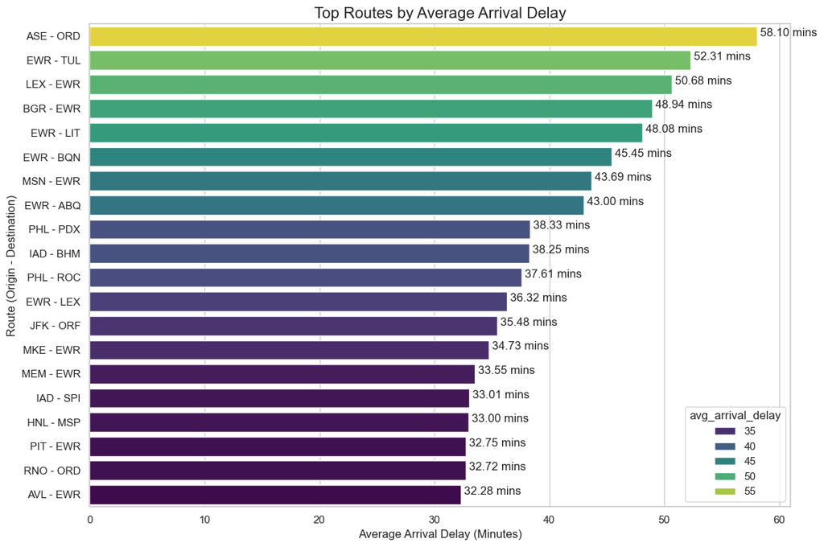

```python
# Sort the DataFrame by avg_arrival_delay in descending order for plotting
df_delays2 = prob_route2.sort_values('avg_arrival_delay', ascending=False)

# Set the seaborn style for a professional look
sns.set_theme(style="whitegrid")

# Create a horizontal bar chart
plt.figure(figsize=(12, 8))
bar_plot = sns.barplot(x='avg_arrival_delay', y='route', data=df_delays2, palette='viridis', hue = 'avg_arrival_delay')

# Add labels to the bars
for index, value in enumerate(df_delays2['avg_arrival_delay']):
    bar_plot.text(value, index, f' {value:.2f} mins')

# Add a title and labels
plt.title('Top Routes by Average Arrival Delay', fontsize=16)
plt.xlabel('Average Arrival Delay (Minutes)', fontsize=12)
plt.ylabel('Route (Origin - Destination)', fontsize=12)

# Ensure the layout is tight
plt.tight_layout()

# Save the plot to a file
plt.savefig('top_routes_delay_plot.png')
```

Additionally, long-haul or cross-country routes such as Philadelphia (PHL) to Portland (PDX) and Washington Dulles (IAD) to Birmingham (BHM) are prone to delays due to airspace congestion, longer flight durations, and greater exposure to variable weather patterns across multiple regions. Overall, the delays on these routes appear to be driven by a combination of airport congestion, route distance, regional weather, and infrastructure limitations.